# Linear Regression, Multiple Regression, and Interactions

Advanced Statistics

2025-11-25

# Introduction

The fundamental equation of statistics is:

$$\text{data} = \text{model} +
\text{error}$$

Our goal is to find models that minimize error while remaining interpretable and generalizable. The **General Linear Model (GLM)** is one of the most powerful frameworks for achieving this goal.

Key terminology:

- **Dependent variable (Y)**: The outcome we want to explain or predict
- **Independent variable (X)**: The variable(s) we use to explain Y

A general linear model expresses the dependent variable as a *linear combination* of independent variables, each multiplied by a weight (β):

$$\hat{y} = \beta_0 + \beta_1 x_1 +
\beta_2 x_2 + \ldots$$

# 14.1 Linear Regression

## Simulating the Data

Let’s create a dataset examining the relationship between study time and exam grades.

```r
library(tidyverse)
library(broom)

# Set seed for reproducibility
set.seed(42)

n <- 8
study_time <- c(0.5, 1, 1.5, 2, 2.5, 3, 3.5, 4)

# Generate grades with a linear relationship + noise
# True relationship: grade = 76 + 4.3 * study_time + error
grade <- 76 + 4.3 * study_time + rnorm(n, mean = 0, sd = 6)

df <- tibble(
  studyTime = study_time,
  grade = grade
)

# View the data
df
```

```
## # A tibble: 8 × 2
##   studyTime grade
##       <dbl> <dbl>
## 1       0.5  86.4
## 2       1    76.9
## 3       1.5  84.6
## 4       2    88.4
## 5       2.5  89.2
## 6       3    88.3
## 7       3.5 100.
## 8       4    92.6
```

## Visualizing the Relationship

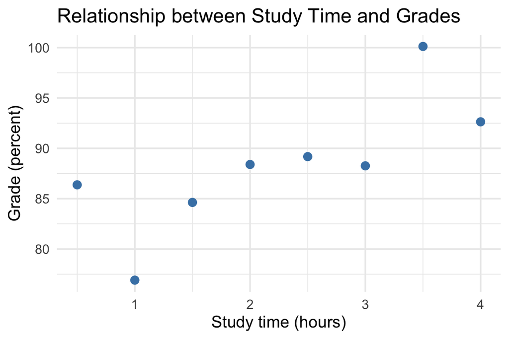

```r
ggplot(df, aes(x = studyTime, y = grade)) +
  geom_point(size = 3, color = "steelblue") +
  labs(
    x = "Study time (hours)",
    y = "Grade (percent)",
    title = "Relationship between Study Time and Grades"
  ) +
  theme_minimal(base_size = 14)
```

## Correlation

Before fitting a regression model, let’s compute the correlation:

```r
cor.test(df$grade, df$studyTime)
```

```
##
##  Pearson's product-moment correlation
##
## data:  df$grade and df$studyTime
## t = 2.8318, df = 6, p-value = 0.02989
## alternative hypothesis: true correlation is not equal to 0
## 95 percent confidence interval:
##  0.1105820 0.9530545
## sample estimates:
##       cor
## 0.7563194
```

The correlation tells us about the *strength* and *direction* of the linear relationship. But regression goes further—it allows us to:

1. **Describe** the relationship with a specific equation
2. **Decide** if the relationship is statistically significant
3. **Predict** new values of Y given X

## The Linear Regression Model

The simple linear regression model is:

$$y = \beta_0 + \beta_1 x +
\epsilon$$

Where:

- $\beta_1$ (slope): How much Y changes for a one-unit increase in X
- $\beta_0$ (intercept): The predicted value of Y when X = 0
- $\epsilon$ (error/residuals): What’s left over after the model fit

For prediction, we drop the error term:

$$\hat{y} = \hat{\beta}_0 + \hat{\beta}_1
x$$

## Fitting the Model in R

```r
model1 <- lm(grade ~ studyTime, data = df)
summary(model1)
```

```
##
## Call:
## lm(formula = grade ~ studyTime, data = df)
##
## Residuals:
##     Min      1Q  Median      3Q     Max
## -6.2966 -2.8985 -0.3898  2.1311  6.7016
##
## Coefficients:
##             Estimate Std. Error t value Pr(>|t|)
## (Intercept)   79.125      3.641  21.732  6.2e-07 ***
## studyTime      4.084      1.442   2.832   0.0299 *
## ---
## Signif. codes:  0 '***' 0.001 '**' 0.01 '*' 0.05 '.' 0.1 ' ' 1
##
## Residual standard error: 4.673 on 6 degrees of freedom
## Multiple R-squared:  0.572,  Adjusted R-squared:  0.5007
## F-statistic: 8.019 on 1 and 6 DF,  p-value: 0.02989
```

### Interpreting the Output

Let’s break down the key components:

- **Intercept** ($\hat{\beta}_0$): The predicted grade when study time = 0
- **studyTime** ($\hat{\beta}_1$): For each additional hour of study, grades increase by this amount
- **R-squared**: Proportion of variance in grades explained by study time
- **F-statistic**: Overall test of model significance

## Visualizing the Regression Line

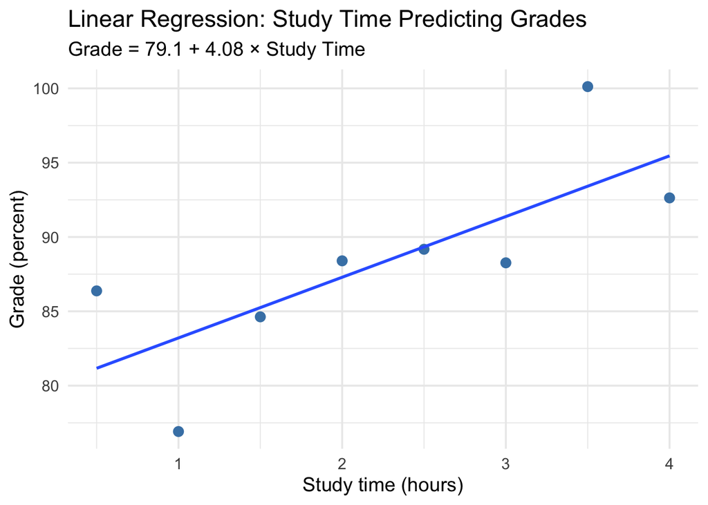

```r
# Get coefficients for annotation
b0 <- coef(model1)[1]
b1 <- coef(model1)[2]

ggplot(df, aes(x = studyTime, y = grade)) +
  geom_point(size = 3, color = "steelblue") +
  geom_smooth(method = "lm", se = FALSE) +
  labs(
    x = "Study time (hours)",
    y = "Grade (percent)",
    title = "Linear Regression: Study Time Predicting Grades",
    subtitle = paste0("Grade = ", round(b0, 1), " + ", round(b1, 2), " × Study Time")
  ) +
  theme_minimal(base_size = 14)
```

## Understanding R-squared

$R^2$ tells us what fraction of the variance in Y is explained by our model:

$$R^2 =
\frac{SS_{model}}{SS_{total}}$$

If the predicted values deviate from the mean in the same way the actual values do, you’ve explained a lot of variance and will result in a high
$$R^2$$

If the predicted values barely move from the mean while the actual values are all over the place, you’ve explained little and will result in a low
$$R^2$$

```r
# Calculate R-squared manually
y_hat <- predict(model1)
ss_total <- sum((df$grade - mean(df$grade))^2)
ss_model <- sum((y_hat - mean(df$grade))^2)

cat("SS_total:", round(ss_total, 2), "\n")
```

```
## SS_total: 306.11
```

```r
cat("SS_model:", round(ss_model, 2), "\n")
```

```
## SS_model: 175.1
```

```r
cat("R-squared:", round(ss_model/ss_total, 3), "\n")
```

```
## R-squared: 0.572
```

# 14.2 Fitting More Complex Models

## Adding a Categorical Predictor

What if some students had prior experience with the material? Let’s extend our dataset:

```r
set.seed(123)

# Expanded dataset with prior class experience
df2 <- tibble(
  studyTime = c(0.5, 1, 2, 3, 0.5, 1.5, 2.5, 4),
  priorClass = factor(c(0, 0, 0, 0, 1, 1, 1, 1)),  # 0 = no, 1 = yes
  # Students with prior class get a boost of ~9 points
  grade = c(
    70 + 5 * 0.5 + rnorm(1, 0, 4),
    70 + 5 * 1 + rnorm(1, 0, 4),
    70 + 5 * 2 + rnorm(1, 0, 4),
    70 + 5 * 3 + rnorm(1, 0, 4),
    70 + 9 + 5 * 0.5 + rnorm(1, 0, 4),
    70 + 9 + 5 * 1.5 + rnorm(1, 0, 4),
    70 + 9 + 5 * 2.5 + rnorm(1, 0, 4),
    70 + 9 + 5 * 4 + rnorm(1, 0, 4)
  )
)

df2
```

```
## # A tibble: 8 × 3
##   studyTime priorClass grade
##       <dbl> <fct>      <dbl>
## 1       0.5 0           70.3
## 2       1   0           74.1
## 3       2   0           86.2
## 4       3   0           85.3
## 5       0.5 1           82.0
## 6       1.5 1           93.4
## 7       2.5 1           93.3
## 8       4   1           93.9
```

## Visualizing the Two Groups

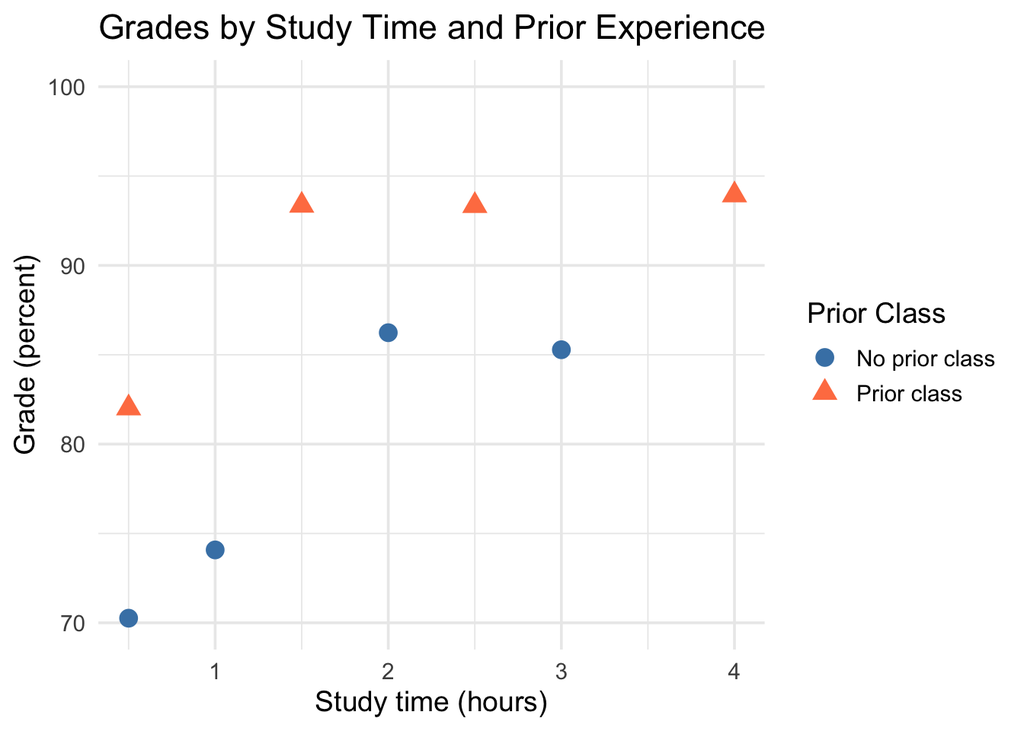

```r
ggplot(df2, aes(x = studyTime, y = grade, color = priorClass, shape = priorClass)) +
  geom_point(size = 4) +
  scale_color_manual(values = c("0" = "steelblue", "1" = "coral"),
                     labels = c("No prior class", "Prior class")) +
  scale_shape_manual(values = c(16, 17),
                     labels = c("No prior class", "Prior class")) +
  coord_cartesian(ylim = c(70, 100)) +
  labs(
    x = "Study time (hours)",
    y = "Grade (percent)",
    title = "Grades by Study Time and Prior Experience",
    color = "Prior Class",
    shape = "Prior Class"
  ) +
  theme_minimal(base_size = 14)
```

## The Multiple Regression Model

We can include both predictors:

$$\hat{y} = \hat{\beta}_0 + \hat{\beta}_1
\times \text{studyTime} + \hat{\beta}_2 \times
\text{priorClass}$$

```r
model2 <- lm(grade ~ studyTime + priorClass, data = df2)
summary(model2)
```

```
##
## Call:
## lm(formula = grade ~ studyTime + priorClass, data = df2)
##
## Residuals:
##       1       2       3       4       5       6       7       8
## -3.9589 -2.2473  5.6891  0.5171 -1.7919  5.3320  1.0963 -4.6364
##
## Coefficients:
##             Estimate Std. Error t value Pr(>|t|)
## (Intercept)   72.107      3.296  21.874 3.71e-06 ***
## studyTime      4.219      1.441   2.928   0.0327 *
## priorClass1    9.592      3.360   2.855   0.0356 *
## ---
## Signif. codes:  0 '***' 0.001 '**' 0.01 '*' 0.05 '.' 0.1 ' ' 1
##
## Residual standard error: 4.641 on 5 degrees of freedom
## Multiple R-squared:  0.8098, Adjusted R-squared:  0.7337
## F-statistic: 10.64 on 2 and 5 DF,  p-value: 0.01578
```

### Interpreting the Coefficients

- **Intercept**: Predicted grade for someone with *no prior class* and *zero study time*
- **studyTime**: Each additional hour increases grade by this amount (same slope for both groups)
- **priorClass1**: Students with prior class score this many points higher on average

## Visualizing the Parallel Lines

With an additive model (no interaction), we’re fitting **parallel lines** with same slope, different intercepts:

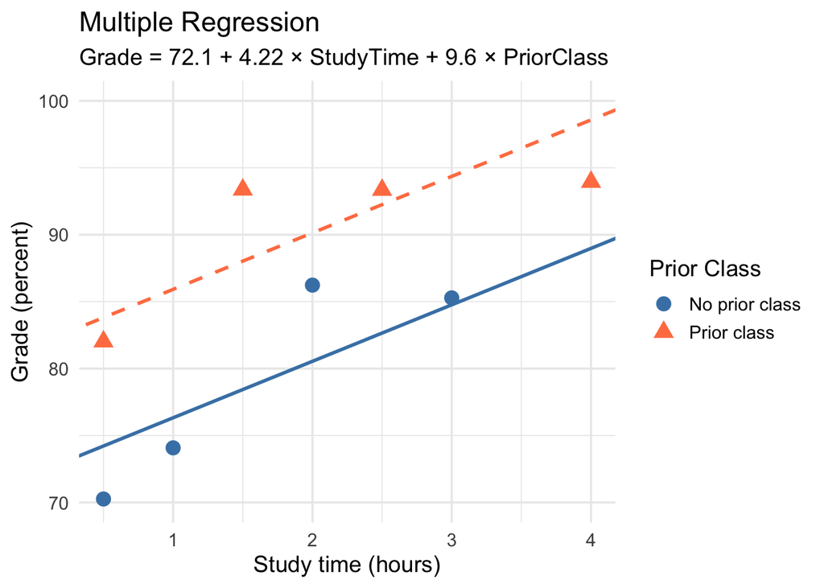

```r
# Get coefficients
b0 <- coef(model2)[1]
b1 <- coef(model2)[2]
b2 <- coef(model2)[3]

ggplot(df2, aes(x = studyTime, y = grade, color = priorClass, shape = priorClass)) +
  geom_point(size = 4) +
  # Line for no prior class
  geom_abline(intercept = b0, slope = b1, color = "steelblue", linewidth = 1) +
  # Line for prior class (intercept shifted by b2)
  geom_abline(intercept = b0 + b2, slope = b1, color = "coral", linewidth = 1, linetype = "dashed") +
  scale_color_manual(values = c("0" = "steelblue", "1" = "coral"),
                     labels = c("No prior class", "Prior class")) +
  scale_shape_manual(values = c(16, 17),
                     labels = c("No prior class", "Prior class")) +
  coord_cartesian(ylim = c(70, 100)) +
  labs(
    x = "Study time (hours)",
    y = "Grade (percent)",
    title = "Multiple Regression",
    subtitle = paste0("Grade = ", round(b0, 1), " + ", round(b1, 2),
                      " × StudyTime + ", round(b2, 1), " × PriorClass"),
    color = "Prior Class",
    shape = "Prior Class"
  ) +
  theme_minimal(base_size = 14)
```

# 14.3 Interactions Between Variables

## A New Example: Caffeine and Public Speaking

Sometimes the effect of one variable *depends on* another variable. This is called an **interaction**.

Let’s simulate data where caffeine affects public speaking differently for anxious vs. non-anxious people:

```r
n_per_group <- 10

# For anxious people: caffeine HURTS performance
# For non-anxious people: caffeine HELPS performance
df3 <- tibble(
  caffeine = rep(seq(10, 100, length.out = n_per_group), 2),
  anxiety = factor(rep(c("anxious", "notAnxious"), each = n_per_group)),
  speaking = c(
    # Anxious: negative slope with caffeine
    17 - 0.47 * seq(10, 100, length.out = n_per_group) + rnorm(n_per_group, 0, 8),
    # Not anxious: positive slope with caffeine
    17 - 43 + 1.08 * seq(10, 100, length.out = n_per_group) + rnorm(n_per_group, 0, 8)
  )
)

head(df3, 12)
```

```
## # A tibble: 12 × 3
##    caffeine anxiety    speaking
##       <dbl> <fct>         <dbl>
##  1       10 anxious        6.81
##  2       20 anxious        4.03
##  3       30 anxious       12.7
##  4       40 anxious        1.08
##  5       50 anxious       -3.29
##  6       60 anxious      -10.3
##  7       70 anxious      -20.3
##  8       80 anxious       -6.30
##  9       90 anxious      -21.3
## 10      100 anxious      -45.7
## 11       10 notAnxious    -9.59
## 12       20 notAnxious    -8.18
```

## Ignoring Anxiety: No Apparent Effect

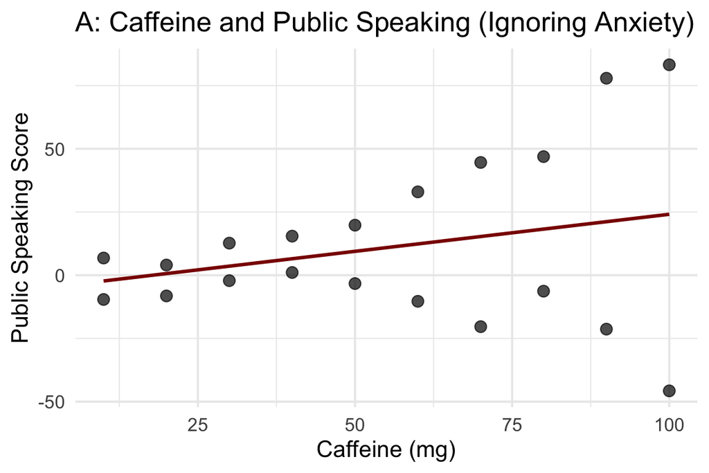

```r
ggplot(df3, aes(x = caffeine, y = speaking)) +
  geom_point(size = 3, alpha = 0.7) +
  geom_smooth(method = "lm", se = FALSE, color = "darkred") +
  labs(
    x = "Caffeine (mg)",
    y = "Public Speaking Score",
    title = "A: Caffeine and Public Speaking (Ignoring Anxiety)"
  ) +
  theme_minimal(base_size = 14)
```

```r
model_simple <- lm(speaking ~ caffeine, data = df3)
summary(model_simple)
```

```
##
## Call:
## lm(formula = speaking ~ caffeine, data = df3)
##
## Residuals:
##     Min      1Q  Median      3Q     Max
## -69.834 -15.228  -1.028  12.907  59.126
##
## Coefficients:
##             Estimate Std. Error t value Pr(>|t|)
## (Intercept)  -5.2080    15.5314  -0.335    0.741
## caffeine      0.2931     0.2503   1.171    0.257
##
## Residual standard error: 32.15 on 18 degrees of freedom
## Multiple R-squared:  0.07078,    Adjusted R-squared:  0.01915
## F-statistic: 1.371 on 1 and 18 DF,  p-value: 0.2569
```

No significant effect! But wait…

## Visualizing by Anxiety Group

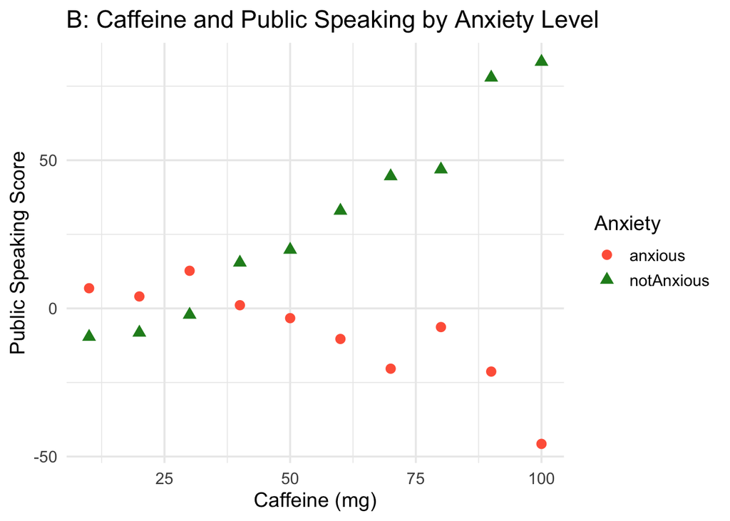

```r
ggplot(df3, aes(x = caffeine, y = speaking, color = anxiety, shape = anxiety)) +
  geom_point(size = 3) +
  scale_color_manual(values = c("anxious" = "tomato", "notAnxious" = "forestgreen")) +
  labs(
    x = "Caffeine (mg)",
    y = "Public Speaking Score",
    title = "B: Caffeine and Public Speaking by Anxiety Level",
    color = "Anxiety",
    shape = "Anxiety"
  ) +
  theme_minimal(base_size = 14)
```

Now we see a very different picture! The effect of caffeine *depends on* anxiety level.

## Additive Model (No Interaction)

What if we add anxiety but don’t allow for an interaction?

```r
model_additive <- lm(speaking ~ caffeine + anxiety, data = df3)
summary(model_additive)
```

```
##
## Call:
## lm(formula = speaking ~ caffeine + anxiety, data = df3)
##
## Residuals:
##    Min     1Q Median     3Q    Max
## -50.65 -18.18  -1.05  15.95  39.94
##
## Coefficients:
##                   Estimate Std. Error t value Pr(>|t|)
## (Intercept)       -24.3899    13.6930  -1.781  0.09276 .
## caffeine            0.2931     0.2003   1.464  0.16157
## anxietynotAnxious  38.3637    11.5045   3.335  0.00392 **
## ---
## Signif. codes:  0 '***' 0.001 '**' 0.01 '*' 0.05 '.' 0.1 ' ' 1
##
## Residual standard error: 25.72 on 17 degrees of freedom
## Multiple R-squared:  0.4382, Adjusted R-squared:  0.3721
## F-statistic: 6.631 on 2 and 17 DF,  p-value: 0.007433
```

Here anxiety has an effect but not caffeine, because we are forcing parallel lines when the slopes are actually opposite!

## The Interaction Model

To allow different slopes for each group, we include an **interaction term**:

$$\hat{y} = \hat{\beta}_0 + \hat{\beta}_1
\times \text{caffeine} + \hat{\beta}_2 \times \text{anxiety} +
\hat{\beta}_3 \times (\text{caffeine} \times
\text{anxiety})$$

In R, we use `*` to include both main effects and their interaction:

```r
model_interaction <- lm(speaking ~ caffeine * anxiety, data = df3)
summary(model_interaction)
```

```
##
## Call:
## lm(formula = speaking ~ caffeine * anxiety, data = df3)
##
## Residuals:
##      Min       1Q   Median       3Q      Max
## -15.1924  -4.9266  -0.0042   4.3268  14.3378
##
## Coefficients:
##                             Estimate Std. Error t value Pr(>|t|)
## (Intercept)                 18.94976    5.41290   3.501  0.00296 **
## caffeine                    -0.49490    0.08724  -5.673 3.46e-05 ***
## anxietynotAnxious          -48.31560    7.65499  -6.312 1.03e-05 ***
## caffeine:anxietynotAnxious   1.57599    0.12337  12.774 8.27e-10 ***
## ---
## Signif. codes:  0 '***' 0.001 '**' 0.01 '*' 0.05 '.' 0.1 ' ' 1
##
## Residual standard error: 7.924 on 16 degrees of freedom
## Multiple R-squared:  0.9498, Adjusted R-squared:  0.9404
## F-statistic:   101 on 3 and 16 DF,  p-value: 1.308e-10
```

### Interpreting the Interaction Model

```r
tidy(model_interaction)
```

```
## # A tibble: 4 × 5
##   term                       estimate std.error statistic  p.value
##   <chr>                         <dbl>     <dbl>     <dbl>    <dbl>
## 1 (Intercept)                  18.9      5.41        3.50 2.96e- 3
## 2 caffeine                     -0.495    0.0872     -5.67 3.46e- 5
## 3 anxietynotAnxious           -48.3      7.65       -6.31 1.03e- 5
## 4 caffeine:anxietynotAnxious    1.58     0.123      12.8  8.27e-10
```

Let’s unpack these coefficients:

- **Intercept** ($\hat{\beta}_0$): Predicted speaking score for *anxious* people with *zero caffeine*
- **caffeine** ($\hat{\beta}_1$): Slope for *anxious* people (caffeine hurts them)
- **anxietynotAnxious** ($\hat{\beta}_2$): Difference in intercept for non-anxious vs. anxious
- **caffeine:anxietynotAnxious** ($\hat{\beta}_3$): How much the slope *changes* for non-anxious people

For anxious people:
$$\text{speaking} =
\hat{\beta}_0 + \hat{\beta}_1 \times \text{caffeine}$$

For non-anxious people:
$$\text{speaking}
= (\hat{\beta}_0 + \hat{\beta}_2) + (\hat{\beta}_1 + \hat{\beta}_3)
\times \text{caffeine}$$

Here we are fitting a different slope and a different intercept for the two group! (previously was just a different intercept)!

## Visualizing the Interaction

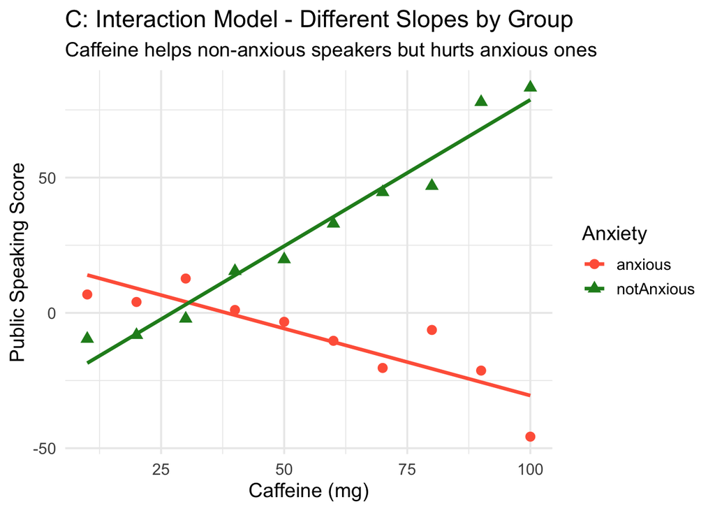

```r
ggplot(df3, aes(x = caffeine, y = speaking, color = anxiety, shape = anxiety)) +
  geom_point(size = 3) +
  geom_smooth(method = "lm", se = FALSE, linewidth = 1.2) +
  scale_color_manual(values = c("anxious" = "tomato", "notAnxious" = "forestgreen")) +
  labs(
    x = "Caffeine (mg)",
    y = "Public Speaking Score",
    title = "C: Interaction Model - Different Slopes by Group",
    subtitle = "Caffeine helps non-anxious speakers but hurts anxious ones",
    color = "Anxiety",
    shape = "Anxiety"
  ) +
  theme_minimal(base_size = 14)
```

## Model Comparison

We can formally compare the additive and interaction models using ANOVA:

```r
anova(model_additive, model_interaction)
```

```
## Analysis of Variance Table
##
## Model 1: speaking ~ caffeine + anxiety
## Model 2: speaking ~ caffeine * anxiety
##   Res.Df     RSS Df Sum of Sq      F    Pr(>F)
## 1     17 11250.0
## 2     16  1004.6  1     10245 163.18 8.273e-10 ***
## ---
## Signif. codes:  0 '***' 0.001 '**' 0.01 '*' 0.05 '.' 0.1 ' ' 1
```

The significant p-value tells us the interaction model fits significantly better than the additive model.

# Key Takeaways

1. **Linear regression** allows us to describe, decide, and predict relationships between variables
2. **Multiple regression** can include multiple predictors, including categorical variables via dummy coding
3. **Interactions** are essential when the effect of one variable depends on another. Without them, we might miss important patterns or conclude there’s “no effect”
4. **Model comparison** helps us determine which model best captures the structure in our data